# Assignment 2 - Supervised learning

## Graph: Personal loan vs Mortgage, Hued by Securities Account

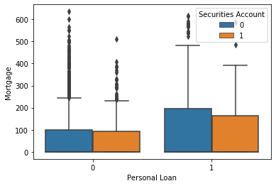

```python
sns.boxplot(x = "Personal Loan", y = "Mortgage", hue = "Securities Account", data = bank_loan_df)
```

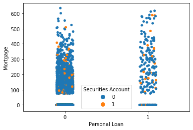

```python
sns.stripplot(x = "Personal Loan", y = "Mortgage", hue = "Securities Account", data = bank_loan_df)
```

## Graph: Personal loan vs Mortgage, Hued by Credit Card

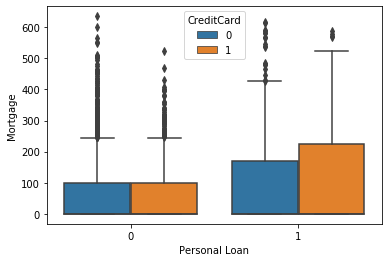

```python
sns.boxplot(x = "Personal Loan", y = "Mortgage", hue = "CreditCard", data = bank_loan_df)
```

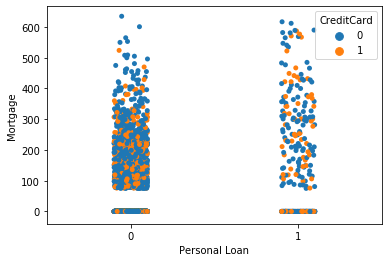

```python
sns.stripplot(x = "Personal Loan", y = "Mortgage", hue = "CreditCard", data = bank_loan_df)
```

## OBSERVATIONS

1. Personal loan takers are more likely to hold a credit card
2. Personal loan takers also have higher mortgages </font>

## Graph: Personal loan vs Mortgage, Hued by CD Account

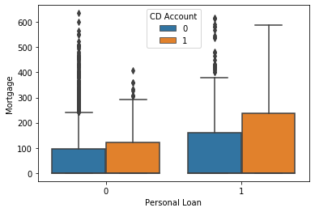

```python
sns.boxplot(x = "Personal Loan", y = "Mortgage", hue = "CD Account", data = bank_loan_df)
```

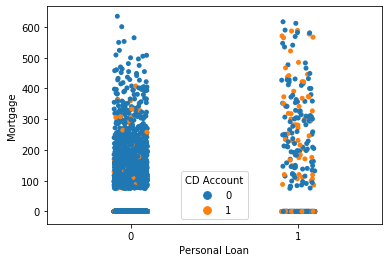

```python
sns.stripplot(x = "Personal Loan", y = "Mortgage", hue = "CD Account", data = bank_loan_df)
```

## OBSERVATIONS

CD account holders are more likely to have a personal loan </font>

## Graph: Personal loan vs Mortgage, Hued by Online

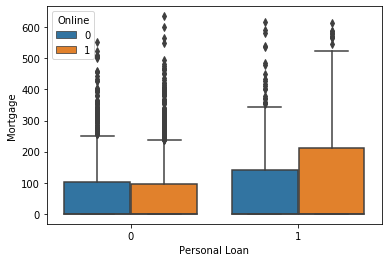

```python
sns.boxplot(x = "Personal Loan", y = "Mortgage", hue = "Online", data = bank_loan_df)
```

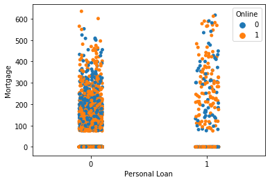

```python
sns.stripplot(x = "Personal Loan", y = "Mortgage", hue = "Online", data = bank_loan_df)
```

## OBSERVATIONS

No additional observations </font>

## Graph: Personal loan vs Age, Hued by Online

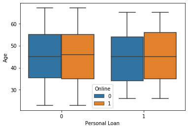

```python
sns.boxplot(x = "Personal Loan", y = "Age", hue = "Online", data = bank_loan_df)
```

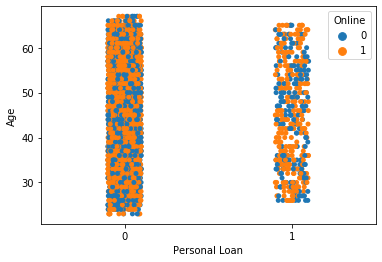

```python
sns.stripplot(x = "Personal Loan", y = "Age", hue = "Online", data = bank_loan_df)
```

## OBSERVATIONS

Age seems to have no impact on personal loans </font>

## Graph: Personal loan vs Age, Hued by CD Account

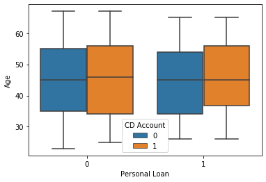

```python
sns.boxplot(x = "Personal Loan", y = "Age", hue = "CD Account", data = bank_loan_df)
```

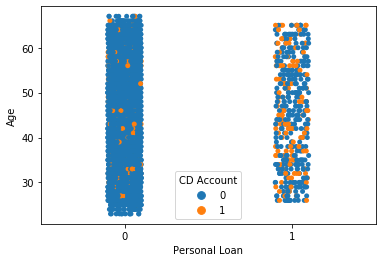

```python
sns.stripplot(x = "Personal Loan", y = "Age", hue = "CD Account", data = bank_loan_df)
```

## OBSERVATIONS

CD account holders are more likely to be personal loan holders also </font>

## Graph: Personal loan vs Age, Hued by Securities Account

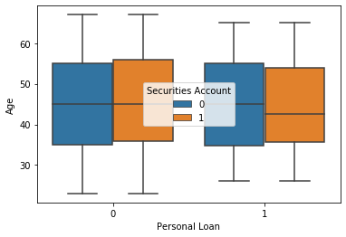

```python
sns.boxplot(x = "Personal Loan", y = "Age", hue = "Securities Account", data = bank_loan_df)
```

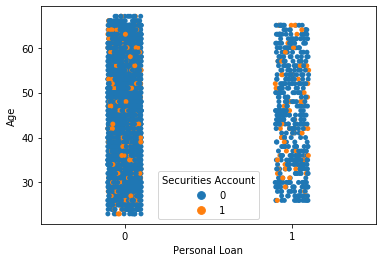

```python
sns.stripplot(x = "Personal Loan", y = "Age", hue = "Securities Account", data = bank_loan_df)
```

## OBSERVATIONS

No Major observation </font>

## Graph: Personal loan vs Age, Hued by Credit Card

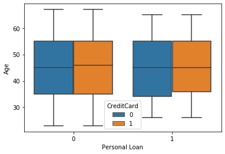

```python
sns.boxplot(x = "Personal Loan", y = "Age", hue = "CreditCard", data = bank_loan_df)
```

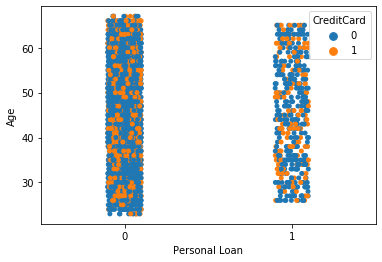

```python
sns.stripplot(x = "Personal Loan", y = "Age", hue = "CreditCard", data = bank_loan_df)
```

## OBSERVATIONS

No Major Observation

</font>

## Graph: Personal loan vs Age, Hued by Family

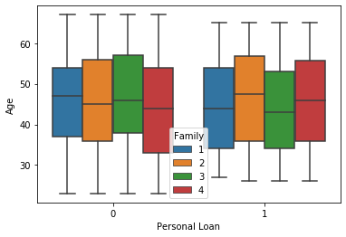

```python
sns.boxplot(x = "Personal Loan", y = "Age", hue = "Family", data = bank_loan_df)
```

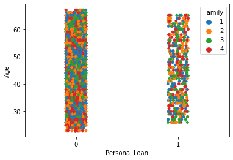

```python
sns.stripplot(x = "Personal Loan", y = "Age", hue = "Family", data = bank_loan_df)
```

## OBSERVATIONS

No Major segregation based on family </font>

## Graph: Personal loan vs Age, Hued by Education

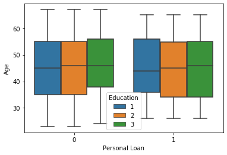

```python
sns.boxplot(x = "Personal Loan", y = "Age", hue = "Education", data = bank_loan_df)
```

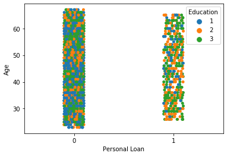

```python
sns.stripplot(x = "Personal Loan", y = "Age", hue = "Education", data = bank_loan_df)
```

## OBSERVATIONS

The proportion of undergrads taking personal loans is far lower than their representation in the population </font>

## Graph: Personal loan vs Income, Hued by Family

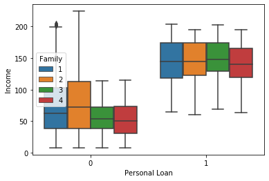

```python
sns.boxplot(x = "Personal Loan", y = "Income", hue = "Family", data = bank_loan_df)
```

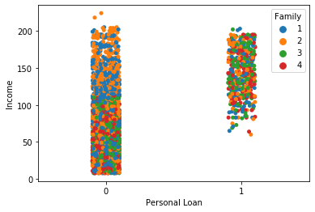

```python
sns.stripplot(x = "Personal Loan", y = "Income", hue = "Family", data = bank_loan_df)
```

## OBSERVATIONS

Families with one kids generally dont consume personal loans </font>

## Graph: Personal loan vs Income, Hued by Education

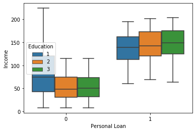

```python
sns.boxplot(x = "Personal Loan", y = "Income", hue = "Education", data = bank_loan_df)
```

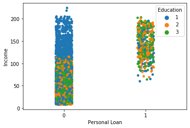

```python
sns.stripplot(x = "Personal Loan", y = "Income", hue = "Education", data = bank_loan_df)
```

## OBSERVATIONS

Undergraduates do not take personal loans that much. The key segment seems to be graduates and advanced studies customers </font>

## Graph: Personal loan vs Mortgage, Hued by Family

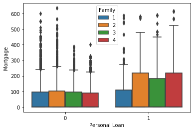

```python
sns.boxplot(x = "Personal Loan", y = "Mortgage", hue = "Family", data = bank_loan_df)
```

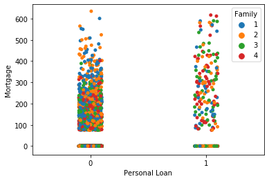

```python
sns.stripplot(x = "Personal Loan", y = "Mortgage", hue = "Family", data = bank_loan_df)
```

## OBSERVATIONS

Lower mortgages seem to correspond to lower % of personal loans. As mortages increase, we see the gap narrowing to almost 1 to 1 ratio </font>

## Graph: Personal loan vs Mortgage, Hued by Education

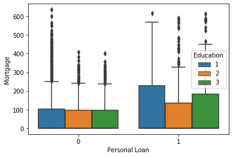

```python
sns.boxplot(x = "Personal Loan", y = "Mortgage", hue = "Education", data = bank_loan_df)
```

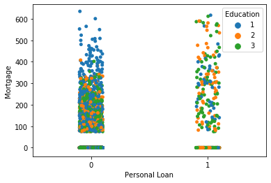

```python
sns.stripplot(x = "Personal Loan", y = "Mortgage", hue = "Education", data = bank_loan_df)
```

## OBSERVATIONS

No additional observations </font>

## Graph: Personal loan vs CCAvg, Hued by Family

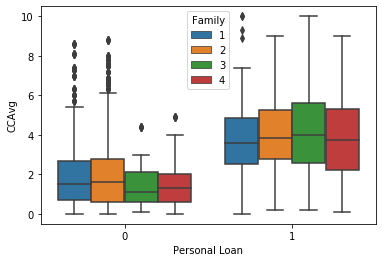

```python
sns.boxplot(x = "Personal Loan", y = "CCAvg", hue = "Family", data = bank_loan_df)
```

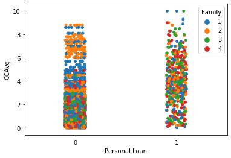

```python
sns.stripplot(x = "Personal Loan", y = "CCAvg", hue = "Family", data = bank_loan_df)
```

## OBSERVATIONS

Higher credit card spend is directly correlated to personal loans </font>

## Graph: Personal loan vs CCAvg, Hued by Education

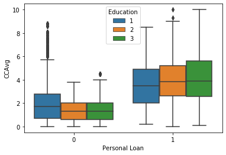

```python
sns.boxplot(x = "Personal Loan", y = "CCAvg", hue = "Education", data = bank_loan_df)
```

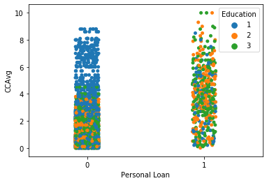

```python
sns.stripplot(x = "Personal Loan", y = "CCAvg", hue = "Education", data = bank_loan_df)
```

## OBSERVATIONS

1. Undergrads spend more on credit cards
2. Grads are more likely to take a loan
3. Personal loan takers spend more on credit cards per month

</font>

## Q6. Done in the beginning (Load dataframe)

## Q7. Ensure the attribute types are correct. If not, take appropriate actions.

```python
bank_loan_df.describe()
```

|  | Age | Experience | Income | Family | CCAvg | Education | Mortgage | Personal Loan | Securities Account | CD Account | Online | CreditCard |
| --- | --- | --- | --- | --- | --- | --- | --- | --- | --- | --- | --- | --- |
| count | 5000.000000 | 5000.000000 | 5000.000000 | 5000.000000 | 5000.000000 | 5000.000000 | 5000.000000 | 5000.000000 | 5000.000000 | 5000.00000 | 5000.000000 | 5000.000000 |
| mean | 45.338400 | 20.104600 | 73.774200 | 2.396400 | 1.937938 | 1.881000 | 56.498800 | 0.096000 | 0.104400 | 0.06040 | 0.596800 | 0.294000 |
| std | 11.463166 | 11.467954 | 46.033729 | 1.147663 | 1.747659 | 0.839869 | 101.713802 | 0.294621 | 0.305809 | 0.23825 | 0.490589 | 0.455637 |
| min | 23.000000 | -3.000000 | 8.000000 | 1.000000 | 0.000000 | 1.000000 | 0.000000 | 0.000000 | 0.000000 | 0.00000 | 0.000000 | 0.000000 |
| 25% | 35.000000 | 10.000000 | 39.000000 | 1.000000 | 0.700000 | 1.000000 | 0.000000 | 0.000000 | 0.000000 | 0.00000 | 0.000000 | 0.000000 |
| 50% | 45.000000 | 20.000000 | 64.000000 | 2.000000 | 1.500000 | 2.000000 | 0.000000 | 0.000000 | 0.000000 | 0.00000 | 1.000000 | 0.000000 |
| 75% | 55.000000 | 30.000000 | 98.000000 | 3.000000 | 2.500000 | 3.000000 | 101.000000 | 0.000000 | 0.000000 | 0.00000 | 1.000000 | 1.000000 |
| max | 67.000000 | 43.000000 | 224.000000 | 4.000000 | 10.000000 | 3.000000 | 635.000000 | 1.000000 | 1.000000 | 1.00000 | 1.000000 | 1.000000 |

```python
bank_loan_df.info()
```

```
<class 'pandas.core.frame.DataFrame'>
Int64Index: 5000 entries, 0 to 4999
Data columns (total 12 columns):
Age                   5000 non-null int64
Experience            5000 non-null int64
Income                5000 non-null int64
Family                5000 non-null int64
CCAvg                 5000 non-null float64
Education             5000 non-null int64
Mortgage              5000 non-null int64
Personal Loan         5000 non-null int64
Securities Account    5000 non-null int64
CD Account            5000 non-null int64
Online                5000 non-null int64
CreditCard            5000 non-null int64
dtypes: float64(1), int64(11)
memory usage: 667.8 KB
```

The attribute types are correct. However, we will have to transform education and family into dummy values

```python
family_dummy = pd.get_dummies(bank_loan_df["Family"], drop_first=True)
```

```python
education_dummy = pd.get_dummies(bank_loan_df["Education"], drop_first=True)
```

```python
bank_loan_updated = pd.concat([bank_loan_df,family_dummy], axis = 1)
```

```python
bank_loan_updated = pd.concat([bank_loan_updated,education_dummy], axis = 1)
```

```python
bank_loan_updated.columns = [               'Age',         'Experience',             'Income',
                   'Family',              'CCAvg',          'Education',
                 'Mortgage',      'Personal Loan', 'Securities Account',
               'CD Account',             'Online',         'CreditCard',
                          "Family_2",                    "Family_3",                    "Family_4",
                          "Education_2",                    "Education_3"]
bank_loan_updated.head()
```

|  | Age | Experience | Income | Family | CCAvg | Education | Mortgage | Personal Loan | Securities Account | CD Account | Online | CreditCard | Family_2 | Family_3 | Family_4 | Education_2 | Education_3 |
| --- | --- | --- | --- | --- | --- | --- | --- | --- | --- | --- | --- | --- | --- | --- | --- | --- | --- |
| 0 | 25 | 1 | 49 | 4 | 1.6 | 1 | 0 | 0 | 1 | 0 | 0 | 0 | 0 | 0 | 1 | 0 | 0 |
| 1 | 45 | 19 | 34 | 3 | 1.5 | 1 | 0 | 0 | 1 | 0 | 0 | 0 | 0 | 1 | 0 | 0 | 0 |
| 2 | 39 | 15 | 11 | 1 | 1.0 | 1 | 0 | 0 | 0 | 0 | 0 | 0 | 0 | 0 | 0 | 0 | 0 |
| 3 | 35 | 9 | 100 | 1 | 2.7 | 2 | 0 | 0 | 0 | 0 | 0 | 0 | 0 | 0 | 0 | 1 | 0 |
| 4 | 35 | 8 | 45 | 4 | 1.0 | 2 | 0 | 0 | 0 | 0 | 0 | 1 | 0 | 0 | 1 | 1 | 0 |

```python
bank_loan_updated = bank_loan_updated.drop(["Family","Education"], axis = 1)
```

We have changed the Education and Family attributes. In later steps we will scale the income, CCAvg, Mortgage and Age/Experience as well

## Q3. Strategies to address the different data challenges such as data pollution, outliers and missing values

Looking at our univariate analysis again

```python
bank_loan_updated.info()
```

```
<class 'pandas.core.frame.DataFrame'>
Int64Index: 5000 entries, 0 to 4999
Data columns (total 15 columns):
Age                   5000 non-null int64
Experience            5000 non-null int64
Income                5000 non-null int64
CCAvg                 5000 non-null float64
Mortgage              5000 non-null int64
Personal Loan         5000 non-null int64
Securities Account    5000 non-null int64
CD Account            5000 non-null int64
Online                5000 non-null int64
CreditCard            5000 non-null int64
Family_2              5000 non-null uint8
Family_3              5000 non-null uint8
Family_4              5000 non-null uint8
Education_2           5000 non-null uint8
Education_3           5000 non-null uint8
dtypes: float64(1), int64(9), uint8(5)
memory usage: 614.1 KB
```

```python
bank_loan_updated.describe()
```

|  | Age | Experience | Income | CCAvg | Mortgage | Personal Loan | Securities Account | CD Account | Online | CreditCard | Family_2 | Family_3 | Family_4 | Education_2 | Education_3 |
| --- | --- | --- | --- | --- | --- | --- | --- | --- | --- | --- | --- | --- | --- | --- | --- |
| count | 5000.000000 | 5000.000000 | 5000.000000 | 5000.000000 | 5000.000000 | 5000.000000 | 5000.000000 | 5000.00000 | 5000.000000 | 5000.000000 | 5000.000000 | 5000.000000 | 5000.000000 | 5000.000000 | 5000.000000 |
| mean | 45.338400 | 20.104600 | 73.774200 | 1.937938 | 56.498800 | 0.096000 | 0.104400 | 0.06040 | 0.596800 | 0.294000 | 0.259200 | 0.202000 | 0.244400 | 0.280600 | 0.300200 |
| std | 11.463166 | 11.467954 | 46.033729 | 1.747659 | 101.713802 | 0.294621 | 0.305809 | 0.23825 | 0.490589 | 0.455637 | 0.438239 | 0.401532 | 0.429774 | 0.449337 | 0.458391 |
| min | 23.000000 | -3.000000 | 8.000000 | 0.000000 | 0.000000 | 0.000000 | 0.000000 | 0.00000 | 0.000000 | 0.000000 | 0.000000 | 0.000000 | 0.000000 | 0.000000 | 0.000000 |
| 25% | 35.000000 | 10.000000 | 39.000000 | 0.700000 | 0.000000 | 0.000000 | 0.000000 | 0.00000 | 0.000000 | 0.000000 | 0.000000 | 0.000000 | 0.000000 | 0.000000 | 0.000000 |
| 50% | 45.000000 | 20.000000 | 64.000000 | 1.500000 | 0.000000 | 0.000000 | 0.000000 | 0.00000 | 1.000000 | 0.000000 | 0.000000 | 0.000000 | 0.000000 | 0.000000 | 0.000000 |
| 75% | 55.000000 | 30.000000 | 98.000000 | 2.500000 | 101.000000 | 0.000000 | 0.000000 | 0.00000 | 1.000000 | 1.000000 | 1.000000 | 0.000000 | 0.000000 | 1.000000 | 1.000000 |
| max | 67.000000 | 43.000000 | 224.000000 | 10.000000 | 635.000000 | 1.000000 | 1.000000 | 1.00000 | 1.000000 | 1.000000 | 1.000000 | 1.000000 | 1.000000 | 1.000000 | 1.000000 |

## OBSERVATION

1. There are negative experience numbers. We need to address this. We have seen from previous multivariate analysis that experience and age correlate very strongly(0.99). Consequently, we are going to drop the entire experience column. This works as the age column contains the same information and does not seem to have the errors in the experience column
2. Lets also examine the 0 CCAvg spending to see if there are changes needed in those rows </font>

```python
bank_loan_updated = bank_loan_updated.drop("Experience", axis = 1)
```

```python
bank_loan_updated[bank_loan_updated["CCAvg"] == 0].sort_values("Mortgage", ascending = False).head(5)
```

|  | Age | Income | CCAvg | Mortgage | Personal Loan | Securities Account | CD Account | Online | CreditCard | Family_2 | Family_3 | Family_4 | Education_2 | Education_3 |
| --- | --- | --- | --- | --- | --- | --- | --- | --- | --- | --- | --- | --- | --- | --- |
| 3662 | 35 | 164 | 0.0 | 500 | 0 | 0 | 0 | 0 | 0 | 1 | 0 | 0 | 0 | 0 |
| 2027 | 38 | 179 | 0.0 | 380 | 0 | 0 | 0 | 0 | 0 | 1 | 0 | 0 | 0 | 0 |
| 3233 | 46 | 111 | 0.0 | 329 | 0 | 0 | 0 | 0 | 0 | 0 | 0 | 0 | 0 | 0 |
| 3979 | 38 | 90 | 0.0 | 258 | 0 | 1 | 1 | 1 | 1 | 1 | 0 | 0 | 0 | 0 |
| 4949 | 29 | 64 | 0.0 | 249 | 0 | 0 | 0 | 0 | 1 | 0 | 0 | 1 | 0 | 0 |

CCAvg depends strongly on Income. Let us plot this clearly to see any deviations

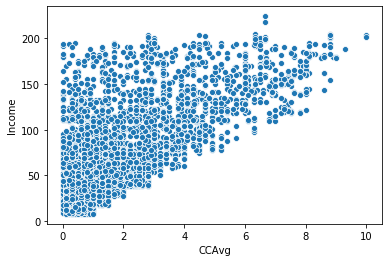

```python
sns.scatterplot(x = "CCAvg", y = "Income", data = bank_loan_updated)
```

## OBSERVATION

The plot looks consistent. Spending on credit card goes up with income. This does not necessitate the cleaning of any data </font>

```python
z_critical = 3
credit_users = bank_loan_df["CCAvg"]
z = np.abs(stat.zscore(credit_users))
print ("Maximum credit card spend per month:",credit_users[z>z_critical].max())
print ("Z Maximum:",z.max())
print ("Deviation count:",credit_users[z>z_critical].count())
```

```
Maximum credit card spend per month: 10.0
Z Maximum: 4.61352496065069
Deviation count: 121
```

## OBSERVATION

The maximum value of credit card spend is 4.6 standard deviations away from the mean. In dollar terms, the maximum credit card spend per month is 10000 dollars. Since the deviation is quite high, let us inspect if someone actually spends more on credit cards than his salary (to understand if this is some sort of data pollution)

```python
bank_loan_df[z>z_critical][bank_loan_df[z>z_critical]["Income"] - (bank_loan_df[z>z_critical]["CCAvg"]*12) < 0]
```

|  | Age | Experience | Income | Family | CCAvg | Education | Mortgage | Personal Loan | Securities Account | CD Account | Online | CreditCard |
| --- | --- | --- | --- | --- | --- | --- | --- | --- | --- | --- | --- | --- |

```python
bank_loan_df[z>z_critical][bank_loan_df[z>z_critical]["Income"] - (bank_loan_df[z>z_critical]["CCAvg"]*12) < 24]
```

|  | Age | Experience | Income | Family | CCAvg | Education | Mortgage | Personal Loan | Securities Account | CD Account | Online | CreditCard |
| --- | --- | --- | --- | --- | --- | --- | --- | --- | --- | --- | --- | --- |

## OBSERVATION

There seem to be no cases where the consumption on credit card exceeds the salary. Infact, the average credit card spending allows atleast 2000 dollars a month to remain with a person. This suggests that the outliers can be allowed to remain

```python
np.isnan(bank_loan_df).sum()
```

```
Age                   0
Experience            0
Income                0
Family                0
CCAvg                 0
Education             0
Mortgage              0
Personal Loan         0
Securities Account    0
CD Account            0
Online                0
CreditCard            0
dtype: int64
```

```python
pd.isna(bank_loan_df).sum()
```

```
Age                   0
Experience            0
Income                0
Family                0
CCAvg                 0
Education             0
Mortgage              0
Personal Loan         0
Securities Account    0
CD Account            0
Online                0
CreditCard            0
dtype: int64
```

## OBSERVATION

There is no missing value in the group either. The data does not need treatment for missing values.

```python
z_critical = 3
mortgage_users = bank_loan_df[bank_loan_df["Mortgage"] > 0]["Mortgage"]
z = np.abs(stat.zscore(mortgage_users))
print ("Max mortgage:", mortgage_users[z>z_critical].max())
print ("Z maximum:",z.max())
print ("Deviation count:",mortgage_users[z>z_critical].count())
```

```
Max mortgage: 635
Z maximum: 4.454075902882071
Deviation count: 27
```

```python
z_critical = 3
income = bank_loan_df[bank_loan_df["Income"] > 0]["Income"]
z = np.abs(stat.zscore(income))
print ("Max income:",income[z>z_critical].max())
print ("Z maximum:", z.max())
print ("Deviation count:", income[z>z_critical].count())
```

```
Max income: 224
Z maximum: 3.2637117837190517
Deviation count: 2
```

## OBSERVATION

Mortgage and Income columns also line up consistently with tolerable z value deviations This means we can move to the next stage

## Q8. Transform the data i.e. scale / normalize if required

We use the MinMaxScaler to reduce Age, Income, CCAvg and Mortgage down to numbers between 0 and 1

```python
bank_loan_updated.head()
```

|  | Age | Income | CCAvg | Mortgage | Personal Loan | Securities Account | CD Account | Online | CreditCard | Family_2 | Family_3 | Family_4 | Education_2 | Education_3 |
| --- | --- | --- | --- | --- | --- | --- | --- | --- | --- | --- | --- | --- | --- | --- |
| 0 | 25 | 49 | 1.6 | 0 | 0 | 1 | 0 | 0 | 0 | 0 | 0 | 1 | 0 | 0 |
| 1 | 45 | 34 | 1.5 | 0 | 0 | 1 | 0 | 0 | 0 | 0 | 1 | 0 | 0 | 0 |
| 2 | 39 | 11 | 1.0 | 0 | 0 | 0 | 0 | 0 | 0 | 0 | 0 | 0 | 0 | 0 |
| 3 | 35 | 100 | 2.7 | 0 | 0 | 0 | 0 | 0 | 0 | 0 | 0 | 0 | 1 | 0 |
| 4 | 35 | 45 | 1.0 | 0 | 0 | 0 | 0 | 0 | 1 | 0 | 0 | 1 | 1 | 0 |

The Age, Income, CCAvg, Mortgage columns are outside the 0-1 range and may bias the outcomes. Lets use the MinMaxScaler to transform these variables into the 0-1 range

</font>

```python
scaler = MinMaxScaler()
```

```python
transformed_columns = scaler.fit_transform(bank_loan_updated[["Age","Income","CCAvg","Mortgage"]])
```

```python
transformed_df = pd.DataFrame(data = transformed_columns, columns = ["Age","Income","CCAvg","Mortgage"])
```

```python
transformed_df.head()
```

|  | Age | Income | CCAvg | Mortgage |
| --- | --- | --- | --- | --- |
| 0 | 0.045455 | 0.189815 | 0.16 | 0.0 |
| 1 | 0.500000 | 0.120370 | 0.15 | 0.0 |
| 2 | 0.363636 | 0.013889 | 0.10 | 0.0 |
| 3 | 0.272727 | 0.425926 | 0.27 | 0.0 |
| 4 | 0.272727 | 0.171296 | 0.10 | 0.0 |

Now we append the transformed variables back into the dataset and update it.

</font>

```python
transformed_df = pd.concat([transformed_df,bank_loan_updated.drop(["Age","Income","CCAvg","Mortgage"],axis = 1)], axis = 1)
```

```python
transformed_df.head()
```

|  | Age | Income | CCAvg | Mortgage | Personal Loan | Securities Account | CD Account | Online | CreditCard | Family_2 | Family_3 | Family_4 | Education_2 | Education_3 |
| --- | --- | --- | --- | --- | --- | --- | --- | --- | --- | --- | --- | --- | --- | --- |
| 0 | 0.045455 | 0.189815 | 0.16 | 0.0 | 0 | 1 | 0 | 0 | 0 | 0 | 0 | 1 | 0 | 0 |
| 1 | 0.500000 | 0.120370 | 0.15 | 0.0 | 0 | 1 | 0 | 0 | 0 | 0 | 1 | 0 | 0 | 0 |
| 2 | 0.363636 | 0.013889 | 0.10 | 0.0 | 0 | 0 | 0 | 0 | 0 | 0 | 0 | 0 | 0 | 0 |
| 3 | 0.272727 | 0.425926 | 0.27 | 0.0 | 0 | 0 | 0 | 0 | 0 | 0 | 0 | 0 | 1 | 0 |
| 4 | 0.272727 | 0.171296 | 0.10 | 0.0 | 0 | 0 | 0 | 0 | 1 | 0 | 0 | 1 | 1 | 0 |

## Q9. Create the training set and test set in ratio of 70:30

```python
y = transformed_df["Personal Loan"]
```

```python
x = transformed_df.drop("Personal Loan", axis = 1)
```

```python
x_train, x_test, y_train, y_test = train_test_split(x, y, test_size = 0.3, random_state = 100)
```

```python
print( x_train ["Age"].count())
print( x_test ["Age"].count())
```

```
3500
1500
```

Based on our distribution plots we know that the number of 1s are signficantly lower than the number of 0s. This means we will likely suffer some bias in the machine learning model. This will be compensated using threshold variation

</font>

## Q10. First create Logistic Regression algorithm. Note the model performance.

```python
logistic_regressor = LogisticRegression(solver = "liblinear")
```

```python
logistic_regressor.fit(x_train, y_train)
```

```
LogisticRegression(C=1.0, class_weight=None, dual=False, fit_intercept=True,
                   intercept_scaling=1, l1_ratio=None, max_iter=100,
                   multi_class='auto', n_jobs=None, penalty='l2',
                   random_state=None, solver='liblinear', tol=0.0001, verbose=0,
                   warm_start=False)
```

```python
y_pred = logistic_regressor.predict(x_test)
```

```python
confusion_matrix(y_test, y_pred)
```

```
array([[1335,    7],
       [  65,   93]], dtype=int64)
```

```python
print(classification_report(y_test, y_pred))
```

```
              precision    recall  f1-score   support

           0       0.95      0.99      0.97      1342
           1       0.93      0.59      0.72       158

    accuracy                           0.95      1500
   macro avg       0.94      0.79      0.85      1500
weighted avg       0.95      0.95      0.95      1500
```

```python
logistic_regressor.score(x_test, y_test)
```

```
0.952
```

```python
accuracy_score(y_pred, y_test)
```

```
0.952
```

### ROC Curve, base prediction

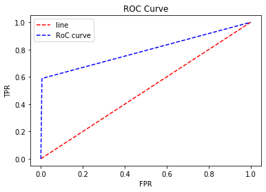

```python
fpr, tpr, thresholds  = roc_curve(y_test, y_pred)
plt.plot([0,1],[0,1],"r--", label = "line")
plt.plot(fpr,tpr,"b--", label = "RoC curve")
plt.xlabel("FPR")
plt.ylabel("TPR")
plt.title("ROC Curve")
plt.legend()
```

The accuracy of this model is 95.2%. Although it suffers from low recall. This can be optimized later using GridSearch

</font>

```python
coef_df = pd.DataFrame(logistic_regressor.coef_)
coef_df['intercept'] = logistic_regressor.intercept_
coef_df['intercept']
```

```
0   -7.981775
Name: intercept, dtype: float64
```

deriving probability scores for the predictions. Will use them to determine FPR, TPR for all thresholds.

```python
y_pred_prob = logistic_regressor.predict_proba(x_test)
y_pred_prob = y_pred_prob[:,1]
```

```python
y_pred = logistic_regressor.predict(x_test)
```

## Q11. Create Roc Curve and calculate the fpr and tpr for all thresholds of the classification

```python
fpr, tpr, thresholds  = roc_curve(y_test, y_pred_prob)
```

### ROC curve All thresholds

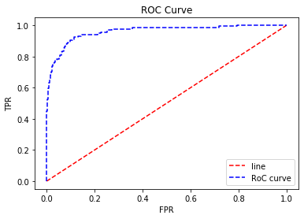

```python
plt.plot([0,1],[0,1],"r--", label = "line")
plt.plot(fpr,tpr,"b--", label = "RoC curve")
plt.xlabel("FPR")
plt.ylabel("TPR")
plt.title("ROC Curve")
plt.legend()
```

```python
cm = confusion_matrix(y_test, y_pred)
```

[output not shown]

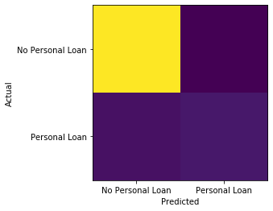

```python
plt.imshow(cm)
plt.ylabel("Actual")
plt.xlabel("Predicted")
plt.xticks([0,1],["No Personal Loan","Personal Loan"])
plt.yticks([0,1],["No Personal Loan","Personal Loan"])
```

## Q12. Logistic Regression with Hyper Parameter Tuning using GridSearchCV

```python
param_grid = {'C':[0.01, 0.1, 1, 10, 100, 1000], 'penalty':['l1','l2','elasticnet']}
# we are adding options for C - inverse of regularization strength (lower values -> greater regularization)
# we are adding options for Penalty - l1, l2, elasticnet are lasso, ridge and elasticnet norms for penalty
#Other parameters could have been solver, class_weight, intercept and a few others as listed in documentation.
#setting the class weight to balanced causes the accuracy to drop
clf = GridSearchCV(logistic_regressor, param_grid = param_grid, cv = 5, verbose=True, n_jobs=-1)

# Fit on data

optimal_logistic_regressor = clf.fit(x_train, y_train)
```

```
Fitting 5 folds for each of 18 candidates, totalling 90 fits
```

```
[Parallel(n_jobs=-1)]: Using backend LokyBackend with 4 concurrent workers.
[Parallel(n_jobs=-1)]: Done  56 tasks      | elapsed:    7.4s
[Parallel(n_jobs=-1)]: Done  90 out of  90 | elapsed:    7.6s finished
```

Predicting the probabilities for later use (all threshold FPR, TPR derivation)

```python
y_pred = optimal_logistic_regressor.predict(x_test)
y_pred_LR_prob = optimal_logistic_regressor.predict_proba(x_test)
```

## Q13. Print Best accuracy and Best Parameters using Confusion Matrix & Print Classification Report to check precision, recall & F1 Score

```python
print (classification_report(y_test,y_pred))
```

```
              precision    recall  f1-score   support

           0       0.96      0.99      0.97      1342
           1       0.85      0.66      0.74       158

    accuracy                           0.95      1500
   macro avg       0.91      0.82      0.86      1500
weighted avg       0.95      0.95      0.95      1500
```

```python
print (confusion_matrix (y_test,y_pred))
```

```
[[1324   18]
 [  54  104]]
```

F1 = 2 *(precision* recall) / (precision + recall) The F1 is a weighted score of precision and recall for a given class. In this case, the optimal values are 0.97 and 0.74. This reflects a bias due to a large number of 0 cases in the target column

The precision is quite high as the number of correct identification cases for 0s is very high. The recall numbers suffer as the large number of 0s also cause a lot of the actual 1s to be classfied incorrectly </font>

```python
optimal_logistic_regressor.best_params_ # best parameters
```

```
{'C': 100, 'penalty': 'l1'}
```

```python
optimal_logistic_regressor.score(x_test,y_test) #best accuracy
```

```
0.952
```

The best score is 0.952/95.2%

### ROC curve All thresholds

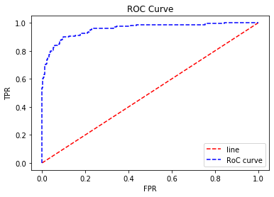

```python
fpr, tpr, thresholds  = roc_curve(y_test, y_pred_LR_prob[:,1])
#Calculating FPR, TPR with probabilities gives us values across all thresholds
plt.plot([0,1],[0,1],"r--", label = "line")
plt.plot(fpr,tpr,"b--", label = "RoC curve")
plt.xlabel("FPR")
plt.ylabel("TPR")
plt.title("ROC Curve")
plt.legend()
```

The accuracy of the model is 95.2%

## Q14. Build KNN algorithm and explain why that algorithm in the comment lines

```python
knn_classifier = KNeighborsClassifier(n_neighbors = 1, metric= "euclidean")
```

### WHY KNN

1. The KNN classifier works on proximity to its neighbours.
2. It is simple to use and understand and avoids the hassles of multiple parameters
3. For similarity detection, recommender systems, KNN is a clean option
4. The only disadvantage of KNN is that it slows down when the data/k is large (complexity of distance calculation with k items) </font>

```python
knn_classifier.fit(x_train, y_train)
```

```
KNeighborsClassifier(algorithm='auto', leaf_size=30, metric='euclidean',
                     metric_params=None, n_jobs=None, n_neighbors=1, p=2,
                     weights='uniform')
```

```python
y_pred = knn_classifier.predict(x_test)
```

```python
print (confusion_matrix(y_test, y_pred))
print (classification_report(y_test, y_pred))
```

```
[[1325   17]
 [  49  109]]
              precision    recall  f1-score   support

           0       0.96      0.99      0.98      1342
           1       0.87      0.69      0.77       158

    accuracy                           0.96      1500
   macro avg       0.91      0.84      0.87      1500
weighted avg       0.95      0.96      0.95      1500
```

```python
error_rate = []
for i in range(1,40):
    knn_classifier = KNeighborsClassifier(n_neighbors = i)
    knn_classifier.fit(x_train, y_train)
    y_pred = knn_classifier.predict(x_test)
    error_rate.append(np.mean(y_pred != y_test))
```

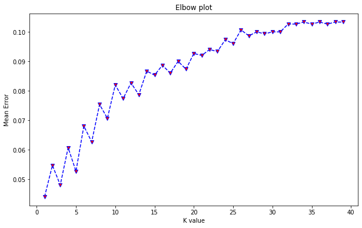

```python
plt.figure(figsize = (10,6))
plt.plot (range(1,40), error_rate, color = 'blue', ls = '--', marker = 'v', markerfacecolor = "red")
plt.title ("Elbow plot")
plt.xlabel("K value")
plt.ylabel("Mean Error")
```

1. The above graph shows us that the value K = 1 seems to be a good choice for this data set.
2. This makes sense as the data is heavily biased towards the 0 value (over 90%)
3. The more the K, the more likely it is to have more 0s in its neighbours

</font>

## Q15. K-Nearest Neighbour with Hyper Parameter Tuning using GridSearchCV. Using Grid Search to identify optimum value for K.

Building a grid search with paramters for leaf_sizes, k (n_neighbors), and customizing the weights as distance

```python
leaf_sizes = list(range(1,30))
n_neighbors_array = list(range(1,40))
param_grid = {'n_neighbors':n_neighbors_array, 'weights': ['distance'], 'leaf_size':leaf_sizes}
# Create grid search object
knn_classifier = KNeighborsClassifier()
clf = GridSearchCV(knn_classifier, param_grid = param_grid, cv = 5, verbose=True, n_jobs=-1)

# Fit on data

optimal_knn_classifier = clf.fit(x_train, y_train)
```

```
Fitting 5 folds for each of 1131 candidates, totalling 5655 fits
```

```
[Parallel(n_jobs=-1)]: Using backend LokyBackend with 4 concurrent workers.
[Parallel(n_jobs=-1)]: Done  42 tasks      | elapsed:    2.5s
[Parallel(n_jobs=-1)]: Done 192 tasks      | elapsed:   20.7s
[Parallel(n_jobs=-1)]: Done 442 tasks      | elapsed:   37.1s
[Parallel(n_jobs=-1)]: Done 792 tasks      | elapsed:   55.4s
[Parallel(n_jobs=-1)]: Done 1296 tasks      | elapsed:  1.3min
[Parallel(n_jobs=-1)]: Done 2396 tasks      | elapsed:  2.0min
[Parallel(n_jobs=-1)]: Done 3696 tasks      | elapsed:  2.8min
[Parallel(n_jobs=-1)]: Done 5196 tasks      | elapsed:  3.5min
[Parallel(n_jobs=-1)]: Done 5648 out of 5655 | elapsed:  3.7min remaining:    0.2s
[Parallel(n_jobs=-1)]: Done 5655 out of 5655 | elapsed:  3.7min finished
```

```python
y_pred = optimal_knn_classifier.predict(x_test)
```

```python
print(classification_report(y_test, y_pred))
```

```
              precision    recall  f1-score   support

           0       0.96      0.99      0.98      1342
           1       0.87      0.69      0.77       158

    accuracy                           0.96      1500
   macro avg       0.91      0.84      0.87      1500
weighted avg       0.95      0.96      0.95      1500
```

```python
print(confusion_matrix(y_test, y_pred))
```

```
[[1325   17]
 [  49  109]]
```

```python
optimal_knn_classifier.best_estimator_
```

```
KNeighborsClassifier(algorithm='auto', leaf_size=1, metric='minkowski',
                     metric_params=None, n_jobs=None, n_neighbors=1, p=2,
                     weights='distance')
```

The below are the optimal paramters based on our inputs (we can try more given a greater computing capacity)

```
algorithm='auto'
leaf_size=1
metric='minkowski',
metric_params=None,
n_jobs=None,
n_neighbors=1,
p=2,
weights='distance'
```

</font>

```python
optimal_knn_classifier.best_params_
```

```
{'leaf_size': 1, 'n_neighbors': 1, 'weights': 'distance'}
```

The optimium K value is 1, the leaf size is also 1

```python
optimal_knn_classifier.score(x_test, y_test)
```

```
0.956
```

```python
accuracy_score (np.array(y_test), y_pred)
```

```
0.956
```

The accuracy of KNN was 95.6%

## Q16. Rebuild the KNN using the optimum value to achieve best accuracy

```python
knn_classifier = KNeighborsClassifier(algorithm='auto', leaf_size=1, metric='minkowski',
                     metric_params=None, n_jobs=None, n_neighbors=1, p=2,
                     weights='distance')
```

```python
knn_classifier.fit(x_train, y_train)
```

```
KNeighborsClassifier(algorithm='auto', leaf_size=1, metric='minkowski',
                     metric_params=None, n_jobs=None, n_neighbors=1, p=2,
                     weights='distance')
```

```python
y_pred = knn_classifier.predict (x_test)
```

## Q17. Print Best accuracy and Best Parameters using Confusion Matrix & Print Classification Report to check precision, recall & F1 Score

```python
accuracy_score(np.array(y_test), y_pred)
```

```
0.956
```

The best accuracy score is 95.6%

```python
print(confusion_matrix(y_test, y_pred))
```

```
[[1325   17]
 [  49  109]]
```

```python
print(classification_report(y_test, y_pred))
```

```
              precision    recall  f1-score   support

           0       0.96      0.99      0.98      1342
           1       0.87      0.69      0.77       158

    accuracy                           0.96      1500
   macro avg       0.91      0.84      0.87      1500
weighted avg       0.95      0.96      0.95      1500
```

```python
knn_classifier.get_params
```

```
<bound method BaseEstimator.get_params of KNeighborsClassifier(algorithm='auto', leaf_size=1, metric='minkowski',
                     metric_params=None, n_jobs=None, n_neighbors=1, p=2,
                     weights='distance')>
```

This is the best KNN model possible for the given data. The best params as mentioned above are p = 2, K(neighbors) = 1, leaf_size = 1 and metric = minkowski (euclidean distance for p = 2)

## Q18.Build Naive Bayes Classifier on training Dataset and explain why that algorithm in the comment lines

```python
nb_loan_model = GaussianNB()
```

### WHY Naive Bayes

A naive bayes classifier can be used in several situations. It has the below advantages

1. It works even when the data is small
2. It is extremely efficient and scalable
3. If there is lots of new data expected, it updates quickly
4. it is insensitive to irrelevant information, which makes it less prone to noise

   </font>

```python
nb_loan_model.fit(x_train, y_train.ravel())
```

```
GaussianNB(priors=None, var_smoothing=1e-09)
```

```python
y_train_pred = nb_loan_model.predict(x_train)
accuracy_score (np.array(y_train), y_train_pred)
```

```
0.8834285714285715
```

## Q19. Print the accuracy of the model & confusion Matrix for Naïve Bayes Model

```python
y_test_pred = nb_loan_model.predict(x_test)
y_test_pred_NB_prob = nb_loan_model.predict_proba(x_test)
accuracy_score (np.array(y_test), y_test_pred)
```

```
0.8826666666666667
```

Accuracy score is 88.2%

y_test_pred_NB_prob is our array of probabilities which will later be used to plot the ROC curve for all thresholds </font>

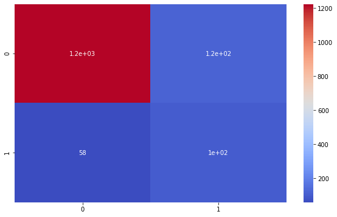

```python
cm = confusion_matrix(y_test, y_test_pred, labels = [0, 1])
plt.figure (figsize = (10,6))
sns.heatmap (cm, annot = True, cmap = "coolwarm")
```

```python
print(cm)
```

```
[[1224  118]
 [  58  100]]
```

## Q20. Explaining Precision, Recall and F1 score

```python
print(classification_report(y_test, y_test_pred))
```

```
              precision    recall  f1-score   support

           0       0.95      0.91      0.93      1342
           1       0.46      0.63      0.53       158

    accuracy                           0.88      1500
   macro avg       0.71      0.77      0.73      1500
weighted avg       0.90      0.88      0.89      1500
```

Precision = True positives/ (True positive + False positive) Precision is the % accuracy in the number of Trues predicted. In this case, it is

1. the number of people who were accurately predicted to not have a personal loan vs the total number of people predicted to not have a personal loan
2. the number of people who were accurately predicted having a personal loan vs the total number of people predicted to have a personal loan

Recall = True positives/ (True positives + False negatives) Recall is the % accuracy in the number of actual Trues. In this case, it is

1. the number of people who were accurately predicted to not have a personal loan vs the actual total number of people who did not have a personal loan
2. the number of people who were accurately predicted having a personal loan vs the actual total number of people who did have a personal loan

The precision and recall is lower for the 1s as the data is signficantly biased towards the 0s (1300 + cases). This means that there is a lot of actual 1s (had personal loan) that were classified as 0s (do not have). This affects both the precision and recall. This can be mitigated using lower thresholds or weighting the samples. In our case, we are proceeding with lower thresholds.

F1 score = 2 *(precision* recall) / (precision + recall) The F1 score is a good mix of precision and recall. It works better than the accuracy measure and can be used when we need to balance both precision and recall </font>

## Q21. Calculate the fpr and tpr for all thresholds of the classification

```python
fpr, tpr, thresholds = roc_curve(y_test, y_test_pred_NB_prob[:, 1])
#Calculating FPR, TPR with probabilities gives us values across all thresholds
```

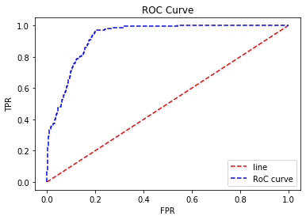

```python
plt.plot([0,1],[0,1],"r--", label = "line")
plt.plot(fpr,tpr,"b--", label = "RoC curve")
plt.xlabel("FPR")
plt.ylabel("TPR")
plt.title("ROC Curve")
plt.legend()
```

## Q22. Firstly, calculate the probabilities of predictions made & then plot the ROC Curve

```python
y_test_prob_pred = nb_loan_model.predict_proba(x_test)
```

predicting probabilities using Naive Bayes

```python
y_test_prob_pred
```

```
array([[9.99979973e-01, 2.00272233e-05],
       [9.98849914e-01, 1.15008573e-03],
       [9.99992116e-01, 7.88434943e-06],
       ...,
       [3.29417868e-01, 6.70582132e-01],
       [9.90537694e-01, 9.46230640e-03],
       [3.22973376e-03, 9.96770266e-01]])
```

```python
y_test_prob_NB = binarize (y_test_prob_pred, 0.2)
```

changing the threshold and binarizing the outcome

```python
np.sum (y_test_prob_NB [:,1])
```

```
258.0
```

```python
print(classification_report(y_test, y_test_prob_NB [:,1]))
```

```
              precision    recall  f1-score   support

           0       0.97      0.89      0.93      1342
           1       0.45      0.73      0.56       158

    accuracy                           0.88      1500
   macro avg       0.71      0.81      0.74      1500
weighted avg       0.91      0.88      0.89      1500
```

```python
fpr, tpr, thresholds  = roc_curve(y_test, y_test_prob_NB [:,1])
```

FPR, TPR calculation

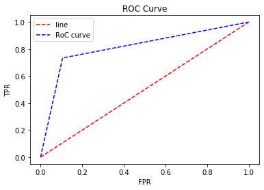

```python
plt.plot([0,1],[0,1],"r--", label = "line")
plt.plot(fpr,tpr,"b--", label = "RoC curve")
plt.xlabel("FPR")
plt.ylabel("TPR")
plt.title("ROC Curve")
plt.legend()
```

### For all Thresholds

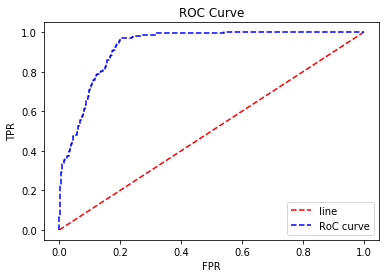

```python
fpr, tpr, thresholds  = roc_curve(y_test, y_test_prob_pred [:,1])
plt.plot([0,1],[0,1],"r--", label = "line")
plt.plot(fpr,tpr,"b--", label = "RoC curve")
plt.xlabel("FPR")
plt.ylabel("TPR")
plt.title("ROC Curve")
plt.legend()
```

## Q23. Evaluate the model. Use confusion matrix to evaluate class level metrics i.e.. Precision and recall. Also reflect the overall score of the model

```python
cm = confusion_matrix(y_test, y_test_pred)
print (cm)
```

```
[[1224  118]
 [  58  100]]
```

```python
print("True 0s", cm [0][0])
print("False 1s", cm [0][1])
print("False 0s", cm [1][0])
print("True 1s", cm [1][1])
```

```
True 0s 1224
False 1s 118
False 0s 58
True 1s 100
```

```python
#Precision = True Positives/ (True positives + False positives)
precision_0 = cm [0][0] / (cm [0][0] + cm [1][0])
precision_0
```

```
0.9547581903276131
```

```python
#Precision = True Positives/ (True positives + False positives)
precision_1 = cm [1][1] / (cm [1][1] + cm [0][1])
precision_1
```

```
0.45871559633027525
```

```python
#Recall = True Positives/ (True positives + False negatives)
recall_0 = cm [0][0] / (cm [0][0] + cm [0][1])
recall_0
```

```
0.9120715350223547
```

```python
#Recall = True Positives/ (True positives + False negatives)
recall_1= cm [1][1] / (cm [1][1] + cm [1][0])
recall_1
```

```
0.6329113924050633
```

```python
print (classification_report(y_test, y_test_pred))
```

```
              precision    recall  f1-score   support

           0       0.95      0.91      0.93      1342
           1       0.46      0.63      0.53       158

    accuracy                           0.88      1500
   macro avg       0.71      0.77      0.73      1500
weighted avg       0.90      0.88      0.89      1500
```

```python
accuracy_score(y_test, y_test_pred)
```

```
0.8826666666666667
```

As can be seen above, the results are an exact match with the precision and recall in the classification report.

The model is good at recognizing 0s accurately. It has a very low rate of incorrectly classified and predicted 0s However, the precision and recall are much lower for recognizing 1s. This is likely due to the inherent bias in the dataset.

The accuracy score is 88.2% </font>

## Q24. Print classification Report for precision, recall & f-1Score for all the models and evaluate them with proper insights

The three models are

1. optimal_logistic_regressor
2. optimal_knn_classifier
3. nb_loan_model </font>

```python
y_pred_LR_probs = optimal_logistic_regressor.predict_proba(x_test)
y_pred_LR_base = optimal_logistic_regressor.predict(x_test)
```

```python
y_pred_KNN = optimal_knn_classifier.predict(x_test)
y_pred_KNN_probs = optimal_knn_classifier.predict_proba(x_test)
y_pred_KNN_probs
```

```
array([[1., 0.],
       [1., 0.],
       [1., 0.],
       ...,
       [0., 1.],
       [1., 0.],
       [1., 0.]])
```

NOTE: Since n = 1 for KNN, the KNN is giving only a binary output for probabilities. This restricts us from providing an ROC curve across all thresholds.

```python
y_pred_NB = nb_loan_model.predict_proba(x_test)
```

```python
y_pred_LR_thresh = binarize(y_pred_LR_probs,0.3)
```

```python
y_pred_NB_thresh = binarize(y_pred_NB,0.3)
```

```python
print ("Logistic Regression---------------------------------------------------------")
print(classification_report(y_test, y_pred_LR_thresh[:,1]))
print ("Logistic Regression---------------------------------------------------------")
```

```
Logistic Regression---------------------------------------------------------
              precision    recall  f1-score   support

           0       0.97      0.97      0.97      1342
           1       0.75      0.75      0.75       158

    accuracy                           0.95      1500
   macro avg       0.86      0.86      0.86      1500
weighted avg       0.95      0.95      0.95      1500

Logistic Regression---------------------------------------------------------
```

```python
print ("KNN---------------------------------------------------------")
print(classification_report(y_test, y_pred_KNN))
print ("KNN---------------------------------------------------------")
```

```
KNN---------------------------------------------------------
              precision    recall  f1-score   support

           0       0.96      0.99      0.98      1342
           1       0.87      0.69      0.77       158

    accuracy                           0.96      1500
   macro avg       0.91      0.84      0.87      1500
weighted avg       0.95      0.96      0.95      1500

KNN---------------------------------------------------------
```

```python
print ("NAIVE BAYES-------------------------------------------------")
print(classification_report(y_test, y_pred_NB_thresh[:,1]))
print ("NAIVE BAYES-------------------------------------------------")
```

```
NAIVE BAYES-------------------------------------------------
              precision    recall  f1-score   support

           0       0.96      0.90      0.93      1342
           1       0.46      0.71      0.56       158

    accuracy                           0.88      1500
   macro avg       0.71      0.80      0.74      1500
weighted avg       0.91      0.88      0.89      1500

NAIVE BAYES-------------------------------------------------
```

The above is a classification report comparision for the three models, We can observe that

1. The Naive Bayes model is the least accurate of the three. This is acceptable considering the highly probabilistic nature of the model as well as its assumptions of independence.
2. The Naive Bayes model struggles with precision in True Personal Loan cases. This is likely because the of the way the data is biased
3. The KNN seems to score strongly across the metrics. Based on the F1 score, it is the best model. However, we see that the logistic regression with the ability to binarize has a better precision and recall balance for cases where personal loan value is "1". Our KNN refused to return probabilities in predict_proba and predicted whole numbers instead, and thus the binarization could not be tested on it. This can be further checked by the area under the ROC curve </font>

## Q25. Roc Curve for Model evaluation and explain the difference among all the models used in your analysis

NOTE: Also completing Q25 in this as it is a part of the calculation

## Q26. Calculate the fpr and tpr for all thresholds of the classification

```python
fpr_LR, tpr_LR, thresholds_LR = roc_curve(y_test, y_pred_LR_thresh[:,1]) ## parameterized
fpr_KNN, tpr_KNN, thresholds_KNN = roc_curve(y_test, y_pred_KNN)
fpr_NB, tpr_NB, thresholds_NB = roc_curve(y_test, y_pred_NB_thresh[:,1]) ## parameterized
fpr_NB_all, tpr_NB_all, thresholds_NB_all = roc_curve(y_test, y_pred_NB[:,1]) ##ALL THRESHOLDS
fpr_LR_b, tpr_LR_b, thresholds_LR_b = roc_curve(y_test, y_pred_LR_base) ##default prediction
fpr_LR_all, tpr_LR_all, thresholds_LR_all = roc_curve(y_test, y_pred_LR_probs[:,1]) ##ALL THRESHOLDS
```

## Q25 Continues

```python
roc_auc_LR = auc(fpr_LR, tpr_LR)
roc_auc_KNN = auc(fpr_KNN, tpr_KNN)
roc_auc_NB = auc(fpr_NB, tpr_NB)
roc_auc_NB_all = auc(fpr_NB_all, tpr_NB_all)
roc_auc_LR_b = auc(fpr_LR_b, tpr_LR_b)
roc_auc_LR_all = auc (fpr_LR_all, tpr_LR_all)
```

```python
print ("Logistic Regression 0.3: ", roc_auc_LR)
print ("Logistic Regression base: ", roc_auc_LR_b)
print ("Logistic Regression all: ", roc_auc_LR_all)
print ("KNN: ", roc_auc_KNN)
print ("Naive Bayes: ", roc_auc_NB)
print ("Naive Bayes all: ", roc_auc_NB_all)
```

```
Logistic Regression 0.3:  0.85888717010319
Logistic Regression base:  0.8224075157048804
Logistic Regression all:  0.9565686958818315
KNN:  0.8386028787564377
Naive Bayes:  0.8048774736365523
Naive Bayes all:  0.9268992057952422
```